# Session 2

Finding Relationships in Your Data

# Last Time

We talked about:

- An introduction to R syntax
- Loading and viewing your data
- R’s data types
- Basic data wrangling

# Agenda

By the end of this workshop, you should be able to understand this block of code:

```r
dat <- read_csv(here("data/dataset.csv"))
admin_dat <- read_csv("data/admin.csv")

dat %>%
  left_join(
    admin_dat %>%
      select(student_id, registration_date),
    by = "student_id"
  ) %>%
  ggplot(aes(registration_date)) +
  geom_histogram() +
  facet_wrap(~ grade)
```

We’ll be covering

- R Markdown
- Combining datasets (joins and binding)
- The wonderful plotting library **ggplot2**

For all of this presentation, I will have the Tidyverse attached and our intervention dataset loaded:

```r
suppressPackageStartupMessages(library(tidyverse))

intervention <- read_csv(
  here::here("data/sample_intervention_dataset.csv"),
  col_types = cols()
)
```

The `col_types = cols()` parameter suppresses the **readr** column specification.

# Combining Data to Make New Data

There are two main kinds of combining datasets together:

1. **Binding** datasets, either binding rows or columns together
2. **Joining** (or **merging**) datasets based on shared information

**Binding** is useful for combining *similarly structured* data.

**Joining** is the more general case where the datasets need not have similar structure but *must* have a common variable (or set of variables).

# Binding

The two primary commands relate to the two *dimensions* of how you can bind data: `bind_rows()` and `bind_cols()` (both from **dplyr**).

I’ll only be discussing `bind_rows()` since `bind_cols()` is *very rarely* the right way to add variables from other datasets into a working dataset, *and* it can be a brittle and potentially dangerous operation.

To motivate the use of `bind_rows()`, I will split the intervention dataset into two datasets, each with its own cohort:

```r
cohort_a <- intervention %>% filter(Cohort == "A")
cohort_b <- intervention %>% filter(Cohort == "B")
```

Row binding is useful when you have *multiple versions* of the same (or similar) datasets and you’d like to combine them into one.

To verify we have different datasets, let’s take a peek at them…

```r
head(cohort_a, 2)
```

| X1 | Coded_ID | Cohort | Intervention | Female | Final_grade | Final_score | Baseline_math_score | Baseline_stereotype_endorsement |
| --- | --- | --- | --- | --- | --- | --- | --- | --- |
| 1 | 1 | A | -1 | 1 | 3.7 | 83.07 | 0.48 | 2 |
| 2 | 2 | A | 1 | 0 | 2.7 | 70.84 | 1.13 | 2 |

```r
head(cohort_b, 2)
```

| X1 | Coded_ID | Cohort | Intervention | Female | Final_grade | Final_score | Baseline_math_score | Baseline_stereotype_endorsement |
| --- | --- | --- | --- | --- | --- | --- | --- | --- |
| 46 | 4 | B | 1 | 1 | 3.7 | 85.20 | -0.54 | 3 |
| 47 | 5 | B | 1 | 0 | 2.7 | 73.88 | 0.37 | 1 |

… and now bound together:

```r
set.seed(1283) # Always set an RNG seed to get reproducible results!

bind_rows(cohort_a, cohort_b) %>%
  slice_sample(n = 5)
```

| X1 | Coded_ID | Cohort | Intervention | Female | Final_grade | Final_score | Baseline_math_score | Baseline_stereotype_endorsement |
| --- | --- | --- | --- | --- | --- | --- | --- | --- |
| 67 | 44 | B | 1 | 0 | 4.0 | 92.71 | -0.02 | 2 |
| 49 | 8 | B | 1 | 1 | 0.7 | 38.56 | -2.24 | 5 |
| 41 | 87 | A | 1 | 0 | 1.0 | 40.30 | 1.13 | 4 |
| 76 | 57 | B | -1 | 0 | 3.7 | 84.76 | 0.76 | 4 |
| 53 | 15 | B | -1 | 1 | 0.7 | 38.91 | 0.11 | 3 |

`slice_sample()` is a function from **dplyr** that picks rows at random, a derivative of `slice()` which filters the dataset to a specific row number range.

If the two datasets have **slightly different** columns (like, reordered columns or some missing columns), `bind_rows()` takes care of this situation by **matching by column *name***.

To show this, I’ll create a different `cohort_b` with some dropped and reordered columns from `cohort_b`.

```r
different_cohort_b <-
  cohort_b %>%
  select(Coded_ID, Intervention:Final_score)
```

The columns of `cohort_b` are `X1`, `Coded_ID`, `Cohort`, `Intervention`, `Female`, `Final_grade`, `Final_score`, `Baseline_math_score`, and `Baseline_stereotype_endorsement`…

…whereas the columns of `different_cohort_b` are `Coded_ID`, `Intervention`, `Female`, `Final_grade`, and `Final_score`.

Row binding them together:

```r
cohort_b %>%
  head(n = 3) %>%
  bind_rows(head(different_cohort_b, 3))
```

| X1 | Coded_ID | Cohort | Intervention | Female | Final_grade | Final_score | Baseline_math_score | Baseline_stereotype_endorsement |
| --- | --- | --- | --- | --- | --- | --- | --- | --- |
| 46 | 4 | B | 1 | 1 | 3.7 | 85.20 | -0.54 | 3 |
| 47 | 5 | B | 1 | 0 | 2.7 | 73.88 | 0.37 | 1 |
| 48 | 7 | B | -1 | 1 | 2.3 | 70.70 | -0.02 | 1 |
| NA | 4 | NA | 1 | 1 | 3.7 | 85.20 | NA | NA |
| NA | 5 | NA | 1 | 0 | 2.7 | 73.88 | NA | NA |
| NA | 7 | NA | -1 | 1 | 2.3 | 70.70 | NA | NA |

Note how `X1` and `Cohort` are filled in with **missingness** (shown as NA) since they don’t exist in `different_cohort_b`.

# Joining & Relational Data

Unlike stacking similar data into a single dataset with row binding, **joining** or **merging** is **the** way to the bring variables from other datasets together<sup>1</sup> based on some shared information called **keys**.

There are two major kinds of keys and one minor but important one to remember:

1. **Primary keys**: Columns that uniquely identify each observed entity in your current dataset (major)
2. **Foreign keys**: Columns that uniquely identify entities in *different* datasets, e.g. a school ID in a child-level dataset (major)
3. **Surrogate keys**: Columns that uniquely identify *each row* (no duplicates!), e.g. a random serial number for each survey submission (minor but important)

Datasets that have these keys that form relations among each other are called **relational data**.

(1): *Column* binding assumes that the row order *and* meaning is same among column-bound datasets which is *very* rarely the case. This is why it’s better to use joins.

To demonstrate joins, I’ll be using the `nycflights13` dataset like *R for Data Science*.

```r
library(nycflights13)
```

It has 5 datasets:

- `flights`: A log of all flights *from* the New York area (JFK, LGA, and EWR) in 2013
- `airlines`: Information on each airline (primary key is `carrier`)
- `airports`: Information on each airport in the flight log (primary key is `faa`)
- `planes`: Information on each plane itself (primary key is `tailnum`)
- `weather`: Hourly readings of the weather at each NY area airport

Source: [Grolemund & Wickham](https://r4ds.had.co.nz/relational-data.html#nycflights13-relational)

There are four main join operations for datasets `x` and `y`:

- `inner_join()`: includes all rows in `x` **and** `y`
- `left_join()`: includes all rows in `x` and *matching* rows in `y`
- `right_join()`: includes all *matching* rows in `x` and all rows in `y`
- `full_join()`: includes all rows in `x` **or** `y`

`left_`, `right_`, and `full_` are all *outer* joins: “left outer join,” “right outer join,” and “full outer join.”

The following slides will *visually* demonstrate how the joins work. Sometimes these are shown as Venn Diagrams, but that can be misleading when duplicates are involved. These visualizations are all from [Grolemund & Wickham](https://r4ds.had.co.nz/relational-data.html#nycflights13-relational).

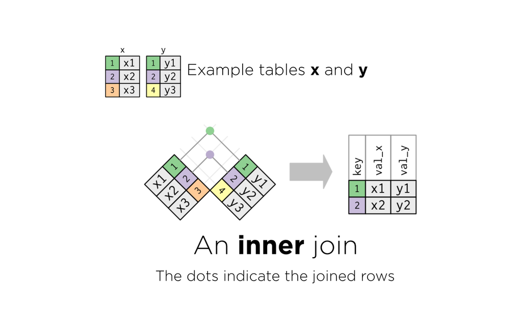

## Outer Joins

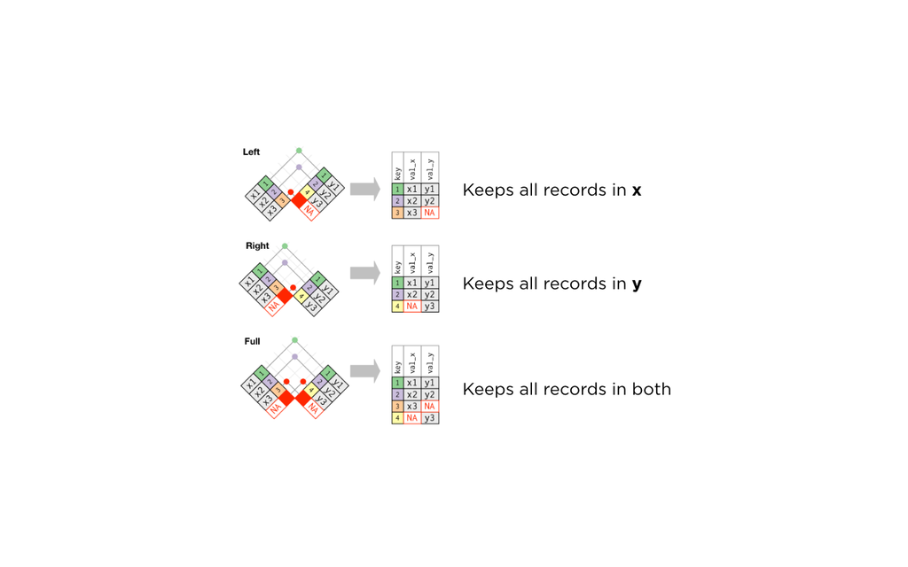

## Duplicates in Key Columns

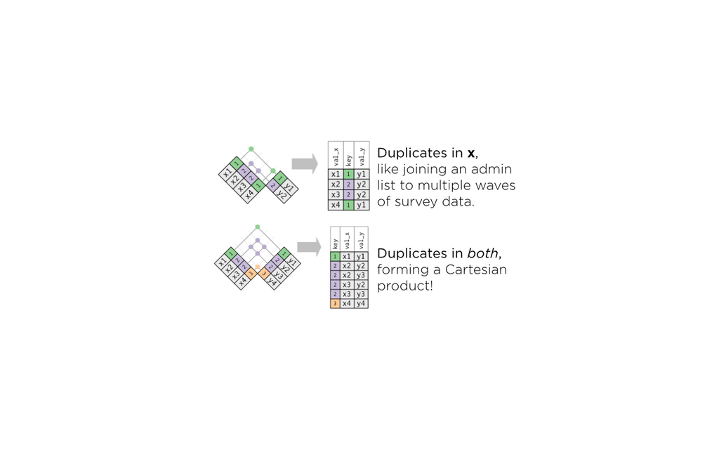

Reflection moment: What would happen if there were $m$ rows of missingness in `x`’s `key` and $n$ rows of missingness in `y`’s `key`? What would that mean for data integrity?

You can also use **multiple columns as a key**, necessary for nested or long-form (e.g. temporal) data.

Suppose we wanted to examine how, on average, adverse weather affected JetBlue’s flights – a necessary calculation for the airline’s dispatch team. We’d need to join JFK’s `weather` reports to the `flights` log:

```r
flights %>%
  filter(origin == "JFK" & carrier == "B6") %>%
  inner_join(
    weather,
    by = c("year", "month", "day", "hour", "origin")
  ) %>%
  head(n = 4)
```

| year | month | day | dep_time | sched_dep_time | dep_delay | arr_time | sched_arr_time | arr_delay | carrier | flight | tailnum | origin | dest | air_time | distance | hour | minute | time_hour.x | temp | dewp | humid | wind_dir | wind_speed | wind_gust | precip | pressure | visib | time_hour.y |
| --- | --- | --- | --- | --- | --- | --- | --- | --- | --- | --- | --- | --- | --- | --- | --- | --- | --- | --- | --- | --- | --- | --- | --- | --- | --- | --- | --- | --- |
| 2013 | 1 | 1 | 544 | 545 | -1 | 1004 | 1022 | -18 | B6 | 725 | N804JB | JFK | BQN | 183 | 1576 | 5 | 45 | 2013-01-01 05:00:00 | 39.02 | 26.96 | 61.63 | 260 | 14.96014 | NA | 0 | 1012.1 | 10 | 2013-01-01 05:00:00 |
| 2013 | 1 | 1 | 557 | 600 | -3 | 838 | 846 | -8 | B6 | 79 | N593JB | JFK | MCO | 140 | 944 | 6 | 0 | 2013-01-01 06:00:00 | 37.94 | 26.96 | 64.29 | 260 | 13.80936 | NA | 0 | 1012.6 | 10 | 2013-01-01 06:00:00 |
| 2013 | 1 | 1 | 558 | 600 | -2 | 849 | 851 | -2 | B6 | 49 | N793JB | JFK | PBI | 149 | 1028 | 6 | 0 | 2013-01-01 06:00:00 | 37.94 | 26.96 | 64.29 | 260 | 13.80936 | NA | 0 | 1012.6 | 10 | 2013-01-01 06:00:00 |
| 2013 | 1 | 1 | 558 | 600 | -2 | 853 | 856 | -3 | B6 | 71 | N657JB | JFK | TPA | 158 | 1005 | 6 | 0 | 2013-01-01 06:00:00 | 37.94 | 26.96 | 64.29 | 260 | 13.80936 | NA | 0 | 1012.6 | 10 | 2013-01-01 06:00:00 |

## Couple Things to Note

```r
flights %>%
  filter(origin == "JFK" & carrier == "B6") %>%
  inner_join(
    weather,
    by = c("year", "month", "day", "hour", "origin")
  )
```

**1)** I only filtered for `origin` because of what the help page for `flights` says! Since datasets can be shared in R packages as well, you can access their data dictionaries with the `?` operator (e.g. `?flights`).

**2)** “B6” is from the `airlines` dataset:

```r
airlines %>% filter(carrier == "B6")
```

| carrier | name |
| --- | --- |
| B6 | JetBlue Airways |

Reflection moment: Why did I use an inner join? Why not use a left outer join?

# Visually Exploring Your Data

Data wrangling and exploratory data analysis would be incomplete without actually **looking** at your data.

### At this stage, we’ll be putting together all we know so far, basic data wrangling and merging to ask all sorts of questions, with plotting to visualize our data.

I’ll continue to try to answer “how, on average, adverse weather affected JetBlue’s flights” visually to introduce…

# `ggplot2`

**ggplot2** is a **huge** package dedicated to implementing the Grammar or Graphics in R. The concept is the idea that **everything in a plot is a layer**, from the input data to geometries to statistics to coordinate transformations. This allows users to **compose** together plot features, similar to how the pipe `%>%` composes together functions.

**ggplot2** is already attached since it’s provided with the **tidyverse** package.

# Intro to ggplot2

Let’s first look at the `precip` column in `weather`. `precip` is the amount of accumulated precipitation in the last hour of measurement. What does its distribution look like?

```r
jfk_weather <-
  weather %>%
  filter(origin == "JFK")
```

To define the input data, we use the `ggplot()` function to start a plot and the `aes()` function to specify the input variables.

```r
jfk_weather %>%
  ggplot(aes(x = precip))
```

`aes(x = )` specifies that this is a 1 variable plot. `aes(x = , y = )` specifies a 2 variable plot.

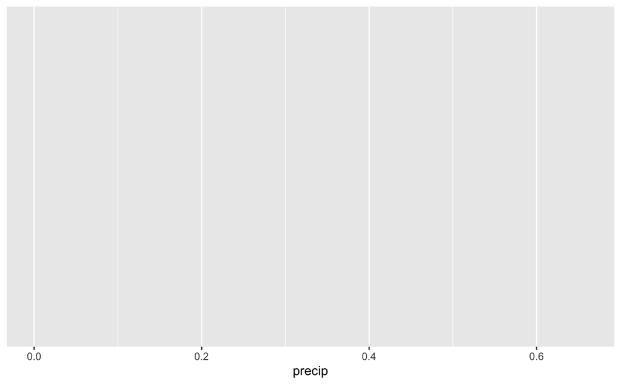

```r
jfk_weather %>%
  ggplot(aes(x = precip)) #<<
```

```r
jfk_flights_weather %>%
  filter(precip > 0) %>%
  select(dep_delay, precip)
```

| dep_delay | precip |
| --- | --- |
| 12 | 0.02 |
| 20 | 0.02 |
| -8 | 0.03 |
| -3 | 0.03 |
| -2 | 0.03 |
| 0 | 0.03 |
| -4 | 0.03 |
| 3 | 0.03 |
| 4 | 0.03 |
| 9 | 0.03 |

[output cut: 990 more lines]

… And visually let’s create a scatter plot with `geom_point()`:

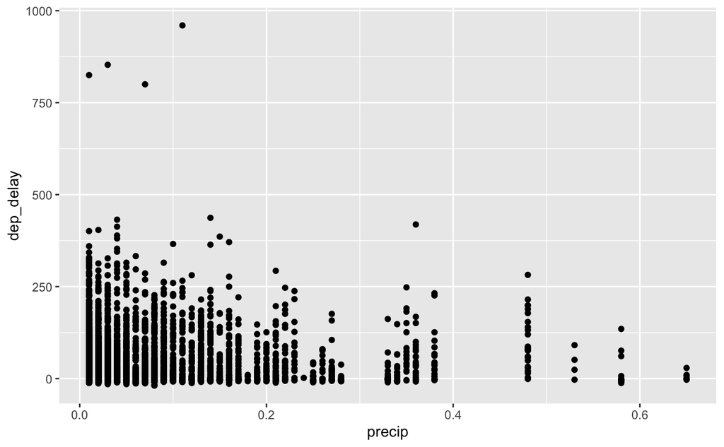

```r
jfk_flights_weather %>%
  filter(precip > 0) %>%
  select(dep_delay, precip) %>%
  ggplot(aes(x = precip, y = dep_delay)) +
  geom_point()
```

Very dense scatter plot! Let’s add a linear fit using the `stat_smooth()` statistic layer for a trendline and add some transparency on the dots to prevent over-plotting.

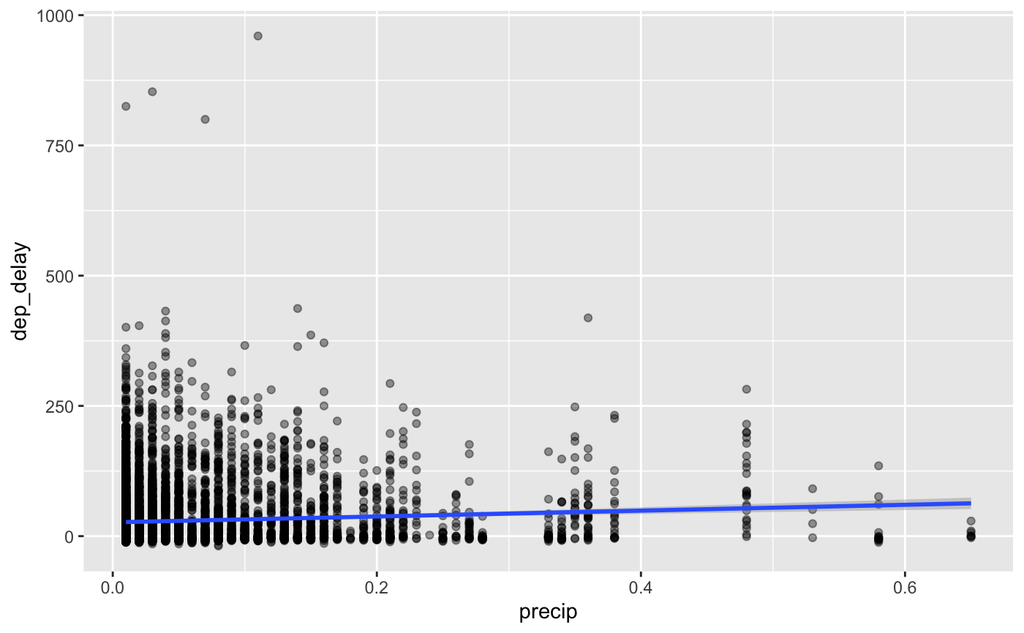

```r
jfk_flights_weather %>%
  filter(precip > 0) %>%
  select(dep_delay, precip) %>%
  ggplot(aes(x = precip, y = dep_delay)) +
  geom_point(alpha = 0.4) +
  stat_smooth(method = "lm") #<<
```

`method = "lm"` refers to using the base R linear model `lm()` function that Michael will discuss later!

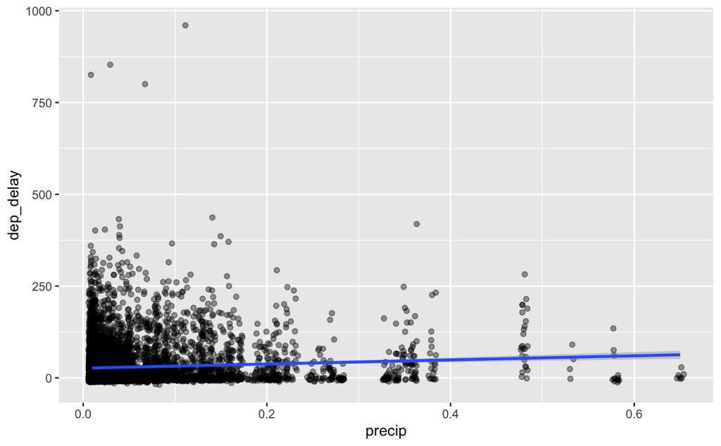

```r
jfk_flights_weather %>%
  filter(precip > 0) %>%
  select(dep_delay, precip) %>%
  ggplot(aes(x = precip, y = dep_delay)) +
  geom_jitter(alpha = 0.4) +
  stat_smooth(method = "lm") #<<
```

We can also use a jitter plot to reduce the regularity in the dots and imply that the measurements are not supposed to be on a grid.

We can show categorical information in several ways. A couple popular methods are with bar plots and different colors.

Let’s look at average departure delay each month by airline:

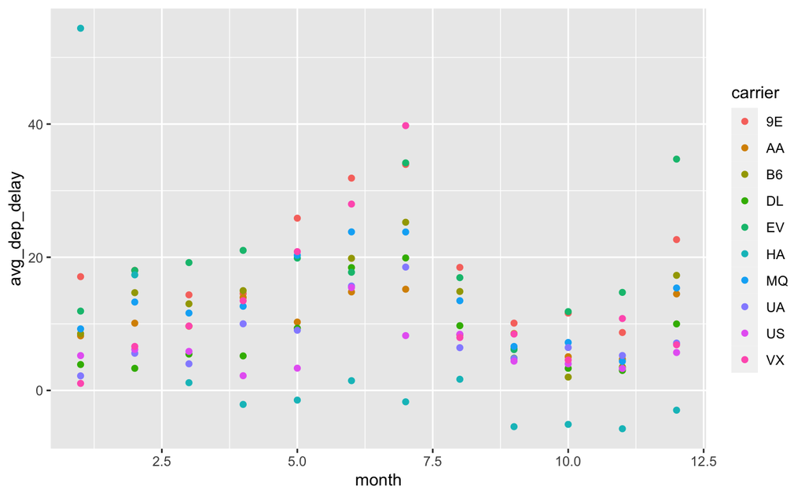

```r
jfk_flights_weather %>%
  mutate(carrier = as.factor(carrier)) %>% #<<
  group_by(carrier, month) %>%
  summarize(avg_dep_delay = mean(dep_delay, na.rm = TRUE)) %>%
  ggplot(aes(
    x = month,
    y = avg_dep_delay,
    color = carrier
  )) +
  geom_point()
```

The `mutate()` statement which converts `carrier` to a factor is necessary since **ggplot2** uses factors for categorical data and does not automatically convert columns passed to the `color` and `fill` parameters.

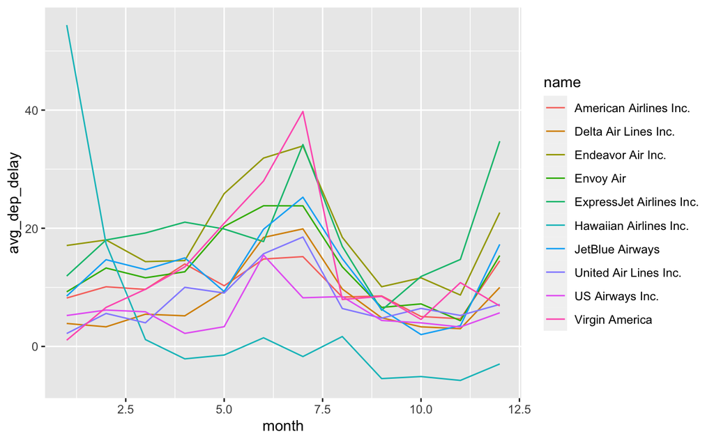

```r
current_plot <- jfk_flights_weather %>%
  left_join(airlines, by = "carrier") %>%
  mutate(name = as.factor(name)) %>%
  group_by(name, month) %>%
  summarize(avg_dep_delay = mean(dep_delay, na.rm = TRUE)) %>%
  ggplot(aes(
    x = month,
    y = avg_dep_delay,
    color = name
  )) +
  geom_line()
current_plot
```

By assigning the plot to a symbol, we can save our work and build upon it in later stages!

To make this publication-ready, we need a few things: a title and good axis labels, some color scale tweaking, and a decent background. I’ll adjust those with `labs()` and some `scale\_\*()` and `theme\_\*()` functions from the fun package **ggthemes**.

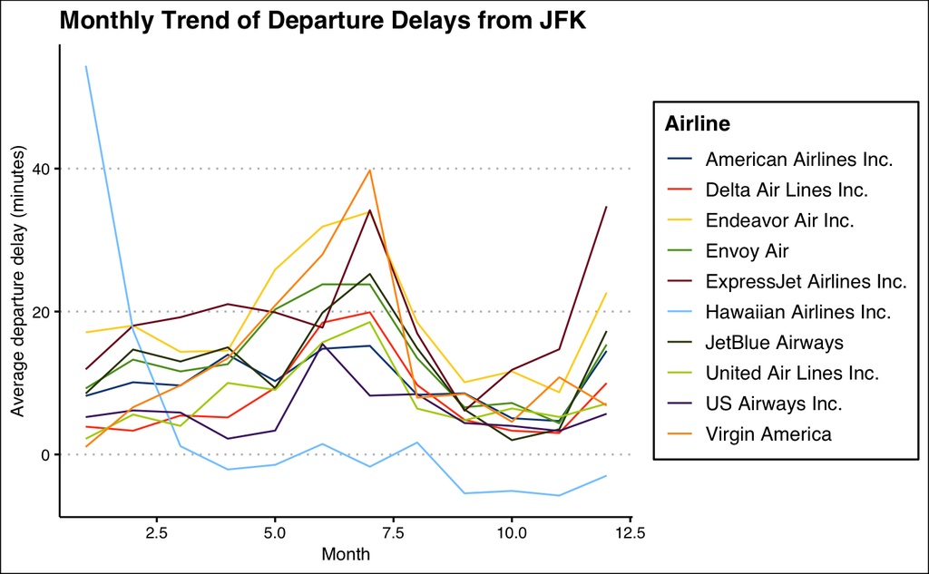

```r
current_plot +
  labs(
    x = "Month",
    y = "Average departure delay (minutes)",
    title = "Monthly Trend of Departure Delays from JFK",
    color = "Airline"
  ) +
  ggthemes::theme_clean() +
  ggthemes::scale_color_calc()
```

For me, there are too many airlines on this plot – it looks like spaghetti. Instead, let’s split geometries into different plots using `facet_wrap()`…

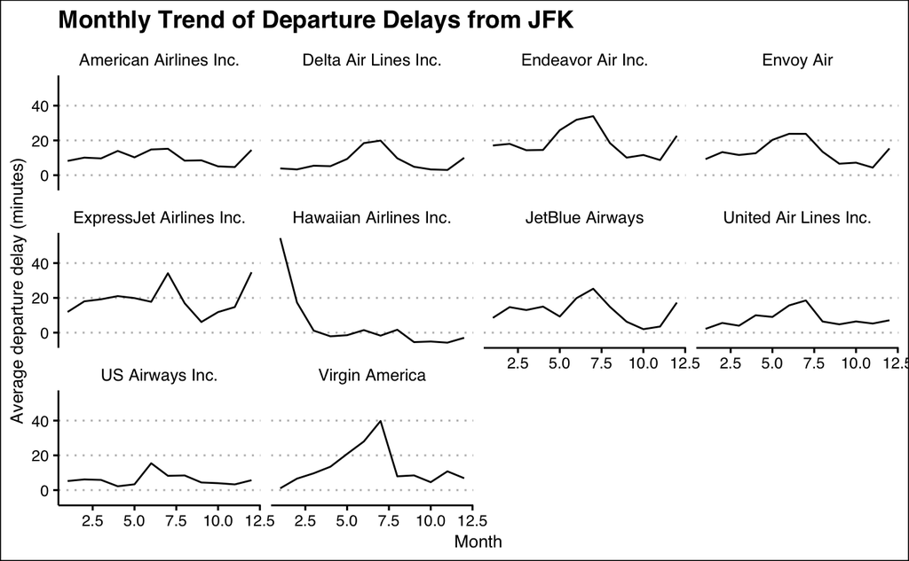

```r
jfk_flights_weather %>%
  left_join(airlines, by = "carrier") %>%
  mutate(name = as.factor(name)) %>%
  group_by(name, month) %>%
  summarize(avg_dep_delay = mean(dep_delay, na.rm = TRUE)) %>%
  ggplot(aes(
    x = month,
    y = avg_dep_delay
  )) +
  geom_line() +
  facet_wrap(~ name) + #<<
  labs(
    x = "Month",
    y = "Average departure delay (minutes)",
    title = "Monthly Trend of Departure Delays from JFK"
  ) +
  ggthemes::theme_clean()
```

`facet_wrap()` partitions the geometries based on the variable specified after the `~` symbol (in R, this denotes a *formula*. Michael will discuss formulae later).

# All in all…

**ggplot2** has an *enormous* amount of power, too much to cover here. Moreover, the topic of data visualization is beyond the scope of this series of workshops. Nevertheless, these are recommended resources for using **ggplot2** and data visualization in R overall:

### [Data Visualization RStudio Cheatsheet](https://github.com/rstudio/cheatsheets/blob/master/data-visualization-2.1.pdf)

*Extremely* handy cheatsheet that covers *most* of what you need to know to work with **ggplot2**. I refer to this almost every time I create plots because I tend to forget which function does what!

### [From Data to Viz](https://www.data-to-viz.com/)

*Beautiful* website that covers data visualization overall, including which situations would require certain kinds of plots and discussions of caveats and traps that people can fall into. The site provides R code snippets for each plot on the site.<sup>1</sup>

(1): It’s written using R Markdown!

# Exercise

Suppose you examine the final score by intervention group. Consult [From Data to Viz](https://www.data-to-viz.com/), and then construct a plot that looks at this relationship. Include any other variables that you deem necessary / interesting!